# Project Overview

## Finding Fraud at Enron

In 2000, Enron was one of the largest companies in the United States. By 2002, it had collapsed into bankruptcy due to widespread corporate fraud. In the resulting Federal investigation, a significant amount of typically confidential information entered into the public record, including tens of thousands of emails and detailed financial data for top executives. In this project, you will play detective, and put your new skills to use by building a person of interest identifier based on financial and email data made public as a result of the Enron scandal.

```python
# import libraries
import sys
import pickle
import matplotlib.pyplot as plt
import numpy as np
from feature_format import featureFormat, targetFeatureSplit
from tester import test_classifier
import pprint
from sklearn.feature_selection import SelectKBest
from sklearn import preprocessing
from sklearn.model_selection import train_test_split
from sklearn.naive_bayes import GaussianNB
from sklearn.tree import DecisionTreeClassifier
from sklearn.ensemble import AdaBoostClassifier
from sklearn.ensemble import RandomForestClassifier
from sklearn.neighbors import KNeighborsClassifier
from sklearn.metrics import accuracy_score
from sklearn.metrics import precision_score
from sklearn.metrics import recall_score
from time import time
from sklearn.metrics import accuracy_score
from sklearn.metrics import precision_score
from sklearn.metrics import recall_score
```

```python
### load the dictionary containing the dataset
with open("final_project_dataset.pkl", "r") as data_file:
    data_dict = pickle.load(data_file)
```

### Question #1:

> Summarize for us the goal of this project and how machine learning is useful in trying to accomplish it. As part of your answer, give some background on the dataset and how it can be used to answer the project question. Were there any outliers in the data when you got it, and how did you handle those? [relevant rubric items: “data exploration”, “outlier investigation”]

#### Investigating the dataset:

Let's start by looking at how many indiduals and how many features our dataset includes.

```python
# print number of people included in the dataset
print("Total number of people in the dataset: {}".format(str(len(data_dict))))
```

```
Total number of people in the dataset: 146
```

```python
# print number of features included in the dataset
print("Total number of features in the dataset: {}".format(str(len(data_dict["SKILLING JEFFREY K"]))))
```

```
Total number of features in the dataset: 21
```

So our dataset includes 146 individuals with 21 features each.

Now let's see what features the dataset contains and it's data type.

```python
# print the features of each individual in the dataset
for key, value in data_dict["SKILLING JEFFREY K"].iteritems() :
    print key, type(value)
```

```
salary <type 'int'>
to_messages <type 'int'>
deferral_payments <type 'str'>
total_payments <type 'int'>
exercised_stock_options <type 'int'>
bonus <type 'int'>
restricted_stock <type 'int'>
shared_receipt_with_poi <type 'int'>
restricted_stock_deferred <type 'str'>
total_stock_value <type 'int'>
expenses <type 'int'>
loan_advances <type 'str'>
from_messages <type 'int'>
other <type 'int'>
from_this_person_to_poi <type 'int'>
poi <type 'bool'>
director_fees <type 'str'>
deferred_income <type 'str'>
long_term_incentive <type 'int'>
email_address <type 'str'>
from_poi_to_this_person <type 'int'>
```

Above we can see the 21 features that the dataset includes on each individual. One of the features present in the dataset is POI. This is an important feature as this is a boolean flag that determines if an idnividual is on of interest. How many individuals in our dataset are flagged as POI?

```python
def poi(file):
    count = 0
    for data in file:
        if file[data]['poi'] == True:
            count += 1
            print data
    print("\nNumber of POIs in the dataset: {} ".format(str(count)))

poi(data_dict)
```

```
HANNON KEVIN P
COLWELL WESLEY
RIEKER PAULA H
KOPPER MICHAEL J
SHELBY REX
DELAINEY DAVID W
LAY KENNETH L
BOWEN JR RAYMOND M
BELDEN TIMOTHY N
FASTOW ANDREW S
CALGER CHRISTOPHER F
RICE KENNETH D
SKILLING JEFFREY K
YEAGER F SCOTT
HIRKO JOSEPH
KOENIG MARK E
CAUSEY RICHARD A
GLISAN JR BEN F

Number of POIs in the dataset: 18
```

18 individuals in out dataset are flagged as POIs.

#### Identifying outliers:

Now that we have an idea of what our dataset looks like, we are going to explore if in outliers exist that should be addressed. We'll start by having a look at three of the main financial datapoints (salary, bonus, and total payments).

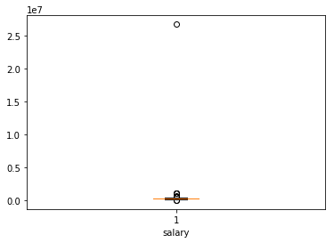

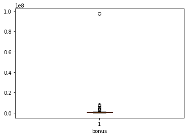

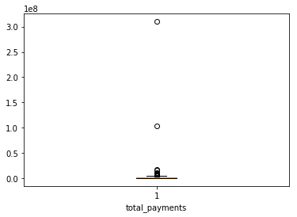

```python
features = ["salary", "bonus", "total_payments"]

for feature in features:
    i = [feature]
    f_data = featureFormat(data_dict, i)
    plt.boxplot(f_data)
    plt.xlabel(feature)
    plt.show()
```

From the three boxplots above it appears that we have at least one extreme outlier in our dataset. If we can identify the outliers, maybe we can deterimine whether the outliers are valid or not.

```python
outliers_salary = []
for key in data_dict:
    value = data_dict[key]['total_payments']
    if value == 'NaN':
        continue
    outliers_salary.append((key,int(value)))

pprint.pprint(sorted(outliers_salary,key=lambda x:x[1],reverse=True)[:5])
```

```
[('TOTAL', 309886585),
 ('LAY KENNETH L', 103559793),
 ('FREVERT MARK A', 17252530),
 ('BHATNAGAR SANJAY', 15456290),
 ('LAVORATO JOHN J', 10425757)]
```

Now we can clearly see that there is a "Total" record that appears to be totaling the values of each of the features. We'll definitly want to get rid of this as it provides no value and skews our data.

```python
data_dict.pop('TOTAL',0)
```

```
{'bonus': 97343619,
 'deferral_payments': 32083396,
 'deferred_income': -27992891,
 'director_fees': 1398517,
 'email_address': 'NaN',
 'exercised_stock_options': 311764000,
 'expenses': 5235198,
 'from_messages': 'NaN',
 'from_poi_to_this_person': 'NaN',
 'from_this_person_to_poi': 'NaN',
 'loan_advances': 83925000,
 'long_term_incentive': 48521928,
 'other': 42667589,
 'poi': False,
 'restricted_stock': 130322299,
 'restricted_stock_deferred': -7576788,
 'salary': 26704229,
 'shared_receipt_with_poi': 'NaN',
 'to_messages': 'NaN',
 'total_payments': 309886585,
 'total_stock_value': 434509511}
```

Now let's have another look at our boxplots.

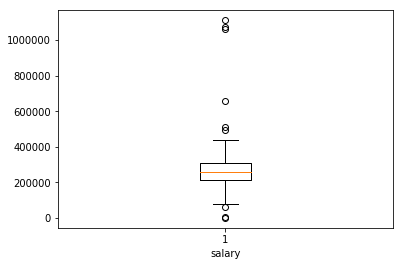

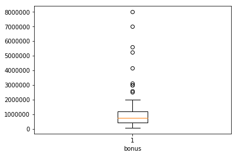

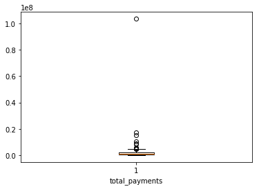

```python
for feature in features:
    i = [feature]
    f_data = featureFormat(data_dict, i)
    plt.boxplot(f_data)
    plt.xlabel(feature)
    plt.show()
```

```python
outliers_total_payments = []
for key in data_dict:
    value = data_dict[key]['total_payments']
    if value == 'NaN':
        continue
    outliers_total_payments.append((key,int(value)))

pprint.pprint(sorted(outliers_total_payments,key=lambda x:x[1],reverse=True)[:5])
```

```
[('LAY KENNETH L', 103559793),
 ('FREVERT MARK A', 17252530),
 ('BHATNAGAR SANJAY', 15456290),
 ('LAVORATO JOHN J', 10425757),
 ('SKILLING JEFFREY K', 8682716)]
```

Though the Total Payments values appeared to be contain outliers, it looks like the records all coincide with an individuals name so should be considered valid data and remain in our dataset.

### Question #2:

> What features did you end up using in your POI identifier, and what selection process did you use to pick them? Did you have to do any scaling? Why or why not? As part of the assignment, you should attempt to engineer your own feature that does not come ready-made in the dataset -- explain what feature you tried to make, and the rationale behind it. (You do not necessarily have to use it in the final analysis, only engineer and test it.) In your feature selection step, if you used an algorithm like a decision tree, please also give the feature importances of the features that you use, and if you used an automated feature selection function like SelectKBest, please report the feature scores and reasons for your choice of parameter values. [relevant rubric items: “create new features”, “intelligently select features”, “properly scale features”]

#### Feature Engineering:

Let's create an initial features list that contains all the quantifiable values included in all of our features. That is to say values that contain information that we could perfomr mathematical calculations on. So all values that are of type int or float. We must also include POI, a boolean value, as the first item in our list.

```python
features_list = ['poi']

for key, value in data_dict["SKILLING JEFFREY K"].iteritems():
    if (isinstance(value, int)):
        if (key not in features_list):
            features_list.append(key)
```

Our dataset includes quite a few good features already, but there's more that could be added.

Lets add one of own to the dataset. We're going to add percent of bonus compared to salary. It may be interesting to see how much these individuals mad in bonuses in relation to thier salaries.

```python
def percent_bonus_to_salary(data_dict, features_list):
    for record in data_dict:
        person = data_dict[record]
        if person['salary'] == 'NaN'or person['bonus'] == 'NaN':
            person['bonus_prct'] = 'NaN'
        else:
            person['bonus_prct'] = float(person['bonus']) / float(person['salary'])
    features_list += ['bonus_prct']

percent_bonus_to_salary(data_dict, features_list)
```

Now to view a record to ensure the new feature was added.

```python
my_dataset = data_dict
print my_dataset["SKILLING JEFFREY K"]
```

```
{'to_messages': 3627, 'deferral_payments': 'NaN', 'expenses': 29336, 'poi': True, 'deferred_income': 'NaN', 'email_address': 'jeff.skilling@enron.com', 'long_term_incentive': 1920000, 'restricted_stock_deferred': 'NaN', 'shared_receipt_with_poi': 2042, 'loan_advances': 'NaN', 'from_messages': 108, '…
```

And there it is, 'bonus_prct': 5.03933380007163. WOW! His bonus reprsents 500% of his salary.

And the updated features list below with bonus_prct.

```python
print features_list
```

```
['poi', 'salary', 'to_messages', 'total_payments', 'exercised_stock_options', 'bonus', 'restricted_stock', 'shared_receipt_with_poi', 'total_stock_value', 'expenses', 'from_messages', 'other', 'from_this_person_to_poi', 'long_term_incentive', 'from_poi_to_this_person', 'bonus_prct']
```

#### Feature Selection:

Now it's time to select the best features from our feature list. For this we will loop through all possible number of features and reveiw the resutls to find the best number of features to use.

```python
def get_Kbest (my_dataset, features_list):
    data = featureFormat(my_dataset, features_list, sort_keys = True)
    labels, features = targetFeatureSplit(data)

    features_train,features_test,labels_train,labels_test = train_test_split(features,labels, test_size=0.3,
                                                                                              random_state=42)

    i = 1
    while i < len(features_list):
        k_best = SelectKBest(k = i)
        k_best.fit(features, labels)
        scores = k_best.scores_
        unsorted_pairs = zip(features_list[1:], scores)
        sorted_pairs = list(reversed(sorted(unsorted_pairs, key=lambda x: x[1])))
        k_best_features = dict(sorted_pairs[:i])
        features_list_test = ['poi'] + k_best_features.keys()
        i += 1

        clf = GaussianNB()

        print("Results with {} features".format(i))
        test_classifier(clf, my_dataset, features_list_test, folds = 1000)


review_all_features = get_Kbest(my_dataset, features_list)
```

```
Results with 2 features
GaussianNB(priors=None, var_smoothing=1e-09)
	Accuracy: 0.90409	Precision: 0.46055	Recall: 0.32100	F1: 0.37831	F2: 0.34171
	Total predictions: 11000	True positives:  321	False positives:  376	False negatives:  679	True negatives: 9624

Results with 3 features
GaussianNB(priors=None, var_smoothing=1e-09)
	Accuracy: 0.84069	Precision: 0.46889	Recall: 0.26750	F1: 0.34066	F2: 0.29264
	Total predictions: 13000	True positives:  535	False positives:  606	False negatives: 1465	True negatives: 10394

Results with 4 features
GaussianNB(priors=None, var_smoothing=1e-09)
	Accuracy: 0.84300	Precision: 0.48581	Recall: 0.35100	F1: 0.40755	F2: 0.37163
	Total predictions: 13000	True positives:  702	False positives:  743	False negatives: 1298	True negatives: 10257

Results with 5 features
GaussianNB(priors=None, var_smoothing=1e-09)
	Accuracy: 0.84677	Precision: 0.50312	Recall: 0.32300	F1: 0.39342	F2: 0.34791
	Total predictions: 13000	True positives:  646	False positives:  638	False negatives: 1354	True negatives: 10362

Results with 6 features
GaussianNB(priors=None, var_smoothing=1e-09)
	Accuracy: 0.84669	Precision: 0.50272	Recall: 0.32300	F1: 0.39330	F2: 0.34787
	Total predictions: 13000	True positives:  646	False positives:  639	False negatives: 1354	True negatives: 10361

Results with 7 features
GaussianNB(priors=None, var_smoothing=1e-09)
	Accuracy: 0.83723	Precision: 0.45748	Recall: 0.31200	F1: 0.37099	F2: 0.33319
	Total predictions: 13000	True positives:  624	False positives:  740	False negatives: 1376	True negatives: 10260

Results with 8 features
GaussianNB(priors=None, var_smoothing=1e-09)
	Accuracy: 0.84564	Precision: 0.44414	Recall: 0.32000	F1: 0.37198	F2: 0.33895
	Total predictions: 14000	True positives:  640	False positives:  801	False negatives: 1360	True negatives: 11199

Results with 9 features
GaussianNB(priors=None, var_smoothing=1e-09)
	Accuracy: 0.84160	Precision: 0.36136	Recall: 0.24500	F1: 0.29201	F2: 0.26186
	Total predictions: 15000	True positives:  490	False positives:  866	False negatives: 1510	True negatives: 12134

```

[output cut: 19 more lines]

```

Results with 14 features
GaussianNB(priors=None, var_smoothing=1e-09)
	Accuracy: 0.83867	Precision: 0.33119	Recall: 0.20600	F1: 0.25401	F2: 0.22285
	Total predictions: 15000	True positives:  412	False positives:  832	False negatives: 1588	True negatives: 12168

Results with 15 features
GaussianNB(priors=None, var_smoothing=1e-09)
	Accuracy: 0.83367	Precision: 0.30888	Recall: 0.20000	F1: 0.24279	F2: 0.21517
	Total predictions: 15000	True positives:  400	False positives:  895	False negatives: 1600	True negatives: 12105

Results with 16 features
GaussianNB(priors=None, var_smoothing=1e-09)
	Accuracy: 0.83473	Precision: 0.31157	Recall: 0.19800	F1: 0.24213	F2: 0.21357
	Total predictions: 15000	True positives:  396	False positives:  875	False negatives: 1604	True negatives: 12125
```

Now we run SelecKBest to determine those features and update our features list.

```python
def get_Kbest (my_dataset, features_list, k):
    data = featureFormat(my_dataset, features_list, sort_keys = True)
    labels, features = targetFeatureSplit(data)

    k_best = SelectKBest(k = k)
    k_best.fit(features, labels)
    scores = k_best.scores_
    unsorted_pairs = zip(features_list[1:], scores)
    sorted_pairs = list(reversed(sorted(unsorted_pairs, key=lambda x: x[1])))
    if k == 'all':
        return sorted_pairs
    else:
        k_best_features = dict(sorted_pairs[:k])
        return k_best_features
    #"{0} best features: {1}\n".format(k, k_best_features.keys())

    #return k_best_features


all_features_ranked = get_Kbest(my_dataset, features_list, 'all')

print all_features_ranked
```

```
[('exercised_stock_options', 25.09754152873549), ('total_stock_value', 24.4676540475264), ('bonus', 21.06000170753657), ('salary', 18.575703268041785), ('bonus_prct', 10.95562707448108), ('long_term_incentive', 10.072454529369441), ('restricted_stock', 9.346700791051488), ('total_payments', 8.866721…
```

```python
best_features = get_Kbest(my_dataset, features_list, 5)

print best_features

features_list = ['poi'] + best_features.keys()
```

```
{'bonus': 21.06000170753657, 'exercised_stock_options': 25.09754152873549, 'salary': 18.575703268041785, 'total_stock_value': 24.4676540475264, 'bonus_prct': 10.95562707448108}
```

Our final features list contains:

- poi
- bonus
- exercised stock options
- salary
- total stock value
- bonus percent

Looks like our new feature we created made it into the final features list.

#### Feaure Scaling:

Feature scaling is a method used to standardize the range of independent variables or features of data. In data processing, it is also known as data normalization and is generally performed during the data preprocessing step. Some algorithms can benefit from feature scaling, or even require feature scaling. As seen below, I will be using the GaussianNB algorithm which does not need feature scaling, so no scaling was performed

### Question #3:

> What algorithm did you end up using? What other one(s) did you try? How did model performance differ between algorithms? [relevant rubric item: “pick an algorithm”]

Now we'll test our data against few algorithms and review the results.

The algorithms we'll be testing are:

- GassianNB
- DecisionTreeClassifier
- AdaBoostClassifier
- RandomForestClassifier
- KNeighborsClassifier

```python
data = featureFormat(my_dataset, features_list, sort_keys = True)
labels, features = targetFeatureSplit(data)

from sklearn.model_selection import train_test_split
features_train, features_test, labels_train, labels_test = \
    train_test_split(features, labels, test_size=0.3, random_state=42)
```

```python
clf_nb = GaussianNB()
clf_dt = DecisionTreeClassifier()
clf_ab = AdaBoostClassifier()
clf_rf = RandomForestClassifier()
clf_kn = KNeighborsClassifier()

classifiers = [clf_nb, clf_dt, clf_ab, clf_rf, clf_kn]

for clf in classifiers:
    test_classifier(clf, my_dataset, features_list, folds = 1000)
```

```
GaussianNB(priors=None, var_smoothing=1e-09)
	Accuracy: 0.84669	Precision: 0.50272	Recall: 0.32300	F1: 0.39330	F2: 0.34787
	Total predictions: 13000	True positives:  646	False positives:  639	False negatives: 1354	True negatives: 10361

DecisionTreeClassifier(class_weight=None, criterion='gini', max_depth=None,
            max_features=None, max_leaf_nodes=None,
            min_impurity_decrease=0.0, min_impurity_split=None,
            min_samples_leaf=1, min_samples_split=2,
            min_weight_fraction_leaf=0.0, presort=False, random_state=None,
            splitter='best')
	Accuracy: 0.78754	Precision: 0.30931	Recall: 0.30900	F1: 0.30915	F2: 0.30906
	Total predictions: 13000	True positives:  618	False positives: 1380	False negatives: 1382	True negatives: 9620

AdaBoostClassifier(algorithm='SAMME.R', base_estimator=None,
          learning_rate=1.0, n_estimators=50, random_state=None)
	Accuracy: 0.79938	Precision: 0.29894	Recall: 0.22600	F1: 0.25740	F2: 0.23759
	Total predictions: 13000	True positives:  452	False positives: 1060	False negatives: 1548	True negatives: 9940
```

```
RandomForestClassifier(bootstrap=True, class_weight=None, criterion='gini',
            max_depth=None, max_features='auto', max_leaf_nodes=None,
            min_impurity_decrease=0.0, min_impurity_split=None,
            min_samples_leaf=1, min_samples_split=2,
            min_weight_fraction_leaf=0.0, n_estimators=10, n_jobs=None,
            oob_score=False, random_state=None, verbose=0,
            warm_start=False)
	Accuracy: 0.84115	Precision: 0.46409	Recall: 0.21000	F1: 0.28916	F2: 0.23582
	Total predictions: 13000	True positives:  420	False positives:  485	False negatives: 1580	True negatives: 10515

KNeighborsClassifier(algorithm='auto', leaf_size=30, metric='minkowski',
           metric_params=None, n_jobs=None, n_neighbors=5, p=2,
           weights='uniform')
	Accuracy: 0.86615	Precision: 0.65971	Recall: 0.26850	F1: 0.38166	F2: 0.30463
	Total predictions: 13000	True positives:  537	False positives:  277	False negatives: 1463	True negatives: 10723
```

After reveiwing the results it looks like KNeighborsClassifier provided the highest accuracy and precision, but fell short on it's recall score. AdaBoostClassifier perfomred the worst with some of the lowest scores across the board. However, GaussianNB provided a good balance between precision and recall.

We will choose to use the **GaussianNB** algorithm.

### Question #4:

> What does it mean to tune the parameters of an algorithm, and what can happen if you don’t do this well? How did you tune the parameters of your particular algorithm? What parameters did you tune? (Some algorithms do not have parameters that you need to tune -- if this is the case for the one you picked, identify and briefly explain how you would have done it for the model that was not your final choice or a different model that does utilize parameter tuning, e.g. a decision tree classifier). [relevant rubric items: “discuss parameter tuning”, “tune the algorithm”]

Tuning parameters for the algorithm is an importnat step. The goal is to set the parameters for the algorithm to optimize it's perfomrance and complete the learning task in the most accurate and effecient way. Through parameter tuning you can fine tune the accuracy, precsion, and recall of the algorithm to obtain the desired resutls. It's very important to note that the desired results should be clearly defined upfront.

The algorithm we chose, GaussianNB, does not have parameters to be tuned, however many of the other algorithms do. DecisionTreeClassifier, for example, has many parameters that can be fine tuned to increase the desried outcome. Parameters like max_depth indicates how deep the tree can be. The deeper the tree, the more splits it has and it captures more information about the data. More isn't always better as the higher value may overfit your model. This could lead to posibly good training, but not so great predictions.

Let's run an example of DecisionTreeClassifier with default values vs. tuned paramaters.

```python
clf_dt = DecisionTreeClassifier()
clf_dt_tuned = DecisionTreeClassifier(max_depth = 2, min_samples_leaf = 4, min_samples_split = 4)

classifiers = [clf_dt, clf_dt_tuned]

for clf in classifiers:
    test_classifier(clf, my_dataset, features_list, folds = 1000)
```

```
DecisionTreeClassifier(class_weight=None, criterion='gini', max_depth=None,
            max_features=None, max_leaf_nodes=None,
            min_impurity_decrease=0.0, min_impurity_split=None,
            min_samples_leaf=1, min_samples_split=2,
            min_weight_fraction_leaf=0.0, presort=False, random_state=None,
            splitter='best')
	Accuracy: 0.78631	Precision: 0.30723	Recall: 0.31000	F1: 0.30861	F2: 0.30944
	Total predictions: 13000	True positives:  620	False positives: 1398	False negatives: 1380	True negatives: 9602

DecisionTreeClassifier(class_weight=None, criterion='gini', max_depth=2,
            max_features=None, max_leaf_nodes=None,
            min_impurity_decrease=0.0, min_impurity_split=None,
            min_samples_leaf=4, min_samples_split=4,
            min_weight_fraction_leaf=0.0, presort=False, random_state=None,
            splitter='best')
	Accuracy: 0.83223	Precision: 0.31864	Recall: 0.07950	F1: 0.12725	F2: 0.09354
	Total predictions: 13000	True positives:  159	False positives:  340	False negatives: 1841	True negatives: 10660
```

I didn't spend much time fine tuning these paramaters, however we can see that tuning the parameters is very important. The parameters passed to the classiier can have wildly different results.

### Question #5:

> What is validation, and what’s a classic mistake you can make if you do it wrong? How did you validate your analysis? [relevant rubric items: “discuss validation”, “validation strategy”]

Model validation is when you take a trained model and evaluate it with a testing set of data. The testing data is a subset of the orignal data. The main dataset is subsetted into two sets of a data, a training set and testing set. The purpose of using the testing data set is to test the generalization ability of a trained model. Validation is performed to ensure that the algorithm generalizes well. One mistake that can be made is over-fitting, where the model is trained and performs well on the training dataset, but much worse on the cross-validation and test datasets. Two ways to perform validation are:

- StratifiedShuffleSplit, folds = 1000 : This can be a good method when the datasets are small and skewed. The chance of splitting data like this and not getting a good mix of samples in each dataset is high. Stratification preserves the percentage of samples from each class, helping to ensure the datasets are repersntative of each other.
- Cross Validation: Cross Validation is a technique which involves reserving a particular sample of a data set on which you do not train the model. Later, you test the model on this sample before finalizing the model.

```python
# GlaussianNB Validation 1 (StratifiedShuffleSplit, folds = 1000)
# Samples are split 70/30. 70% training, 30% testin
t0 = time()
test_classifier(clf_nb, my_dataset, features_list)
print 'Processing time:', round(time() - t0, 3), 's'
```

```
GaussianNB(priors=None, var_smoothing=1e-09)
	Accuracy: 0.84669	Precision: 0.50272	Recall: 0.32300	F1: 0.39330	F2: 0.34787
	Total predictions: 13000	True positives:  646	False positives:  639	False negatives: 1354	True negatives: 10361

Processing time: 0.965 s
```

```python
# GlaussianNB Validation 2  (Cross validation)
# Computing the score 5 consecutive times (with different splits each time)
from sklearn.model_selection import cross_val_score
t0 = time()
scores = cross_val_score(clf_nb, features, labels, cv=5,scoring = 'accuracy')
print("Accuracy and Deviation: " + str((scores.mean(), scores.std() * 2)))
print 'Processing time:', round(time() - t0, 3), 's'
test_classifier(clf_nb, my_dataset, features_list)
```

```
Accuracy and Deviation: (0.8548717948717949, 0.1065820396268209)
Processing time: 0.015 s
GaussianNB(priors=None, var_smoothing=1e-09)
	Accuracy: 0.84669	Precision: 0.50272	Recall: 0.32300	F1: 0.39330	F2: 0.34787
	Total predictions: 13000	True positives:  646	False positives:  639	False negatives: 1354	True negatives: 10361
```

The ShuffledFoldSplit method was used to validate my algorithm.

### Question #6:

> Give at least 2 evaluation metrics and your average performance for each of them. Explain an interpretation of your metrics that says something human-understandable about your algorithm’s performance. [relevant rubric item: “usage of evaluation metrics”]

The two main evalution metrics considered were precision and recall.

Precision is defined as the number of true positives over the number of true positives plus the number of false positives. $P=\frac{Tp}{Tp+Fp}$

Recall is defined as the number of true positives over the number of true positives plus the number of false negatives. $R=\frac{Tp}{Tp+Fn}$

Precision and recall are two of the most important metrics in an algorithm, probably more impotant than accuracy.

Precision is the ability of a classification model to identify only the relevant data points, where as recall is the ability of a model to find all the relevant cases within a dataset.